# 1 IPIP-NEO-120

Johannes Titz

original date: 12/10/2021, revision 06/01/2023

## Prepration

This is analysis 1 of the paper. First, install the `star` package:

```r
if (!require("star")) {
  install.packages("star_0.1.0.tar.gz", repos = NULL, type = "source")
}
```

Load some packages. I will use librarian for installing/loading packages.

```r
if (!require('librarian')) install.packages('librarian')
librarian::shelf(tidyr, dplyr, ggplot2, cowplot, corrgram, ggraph, igraph,
                 GGally, network, ggnetwork, tidygraph, furrr, star,
                 progressr, simpleCache, lavaanPlot, lavaan, DiagrammeRsvg,
                 rsvg)
```

Helper function to get means+se.

```r
get_stats <- function(var, df) {
means <- df %>%
  group_by(.data[[var]]) %>%
  summarize(mean = mean(sum_score, na.rm = TRUE),
            se = sd(sum_score, na.rm = TRUE) / length(na.omit(sum_score)))
  names(means)[1] <- "group"
  means
}
```

Set cache dir for simpleCache:

```r
setCacheDir("cache")
```

load labels for ipip

```r
labels <- create_ipip_neo_items()
```

The original data is available at https://osf.io/tbmh5/ It is too large to make it available through `data`, but `star` has the data set under inst/extdata:

```r
fpath <- system.file("extdata", "ipipneo.rda", package = "star")
if (!exists("ipipneo")) load(fpath)
```

Set simulation parameters. If you use the cache folder (the default), the simulations will not be run again. If you want to rerun the simulation, just remove the cache files or the whole folder.

I am on GNU/Linux, please check that the detection of cores works for you. If it does not work, just set it to a fixed value. `star` uses `parallel` for parallel computation. Sorry, Windows users, parallelization only works under GNU/Linux. You should still be able to run the code, but you cannot take advantage of multiple cores. I tried to implement parallelization via futures (`furrr`), but this turned out to be slower than using a single core.

```r
mc_cores <- round(parallel::detectCores() - 1)
alpha <- 0.05 / (24 * 23 * 5)
param <- sim_parameters(n_bootstrap_samples = 10, mc_cores = mc_cores)
```

## first analysis, with only 10 simulation runs, only keep p-values of 0

```r
set.seed(5989)
simpleCache(
  "ipipneo10",
  {test_items_against_dimension(names(ipipneo), ipipneo, param)},
  timer = TRUE
)
left_items <- extract_sig_items(ipipneo10, 0)
```

Check how many items could not be tested properly:

```r
ipipneo10 %>%
  group_by(i) %>%
  summarize(warn = mean(var0 + n_min_violated > 0)) %>%
  filter(warn > 0)
```

```
## # A tibble: 0 × 2
## # … with 2 variables: i <chr>, warn <dbl>
```

None.

## Stepwise tests with more bootstrap samples

The code is not pretty, maybe accumulate can be used here?

```r
steps <- c(1e2, 1e3, 1e4, 1e5)
result <- ipipneo10
for (step in steps) {
  param$n_bootstrap_samples <- step
  simpleCache(
    paste0("stepwise", step),
    {test_specific_items(ipipneo, result$i, result$j, param)},
    timer = TRUE,
    assignTo = "result",
  )
  result <- result[result$p <= alpha, ]
}
result$group <- substr(result$i, 1, 1)
result <- left_join(result, labels, by = c("i" = "item_char"))
# a better deviance value for network graph
result <- result %>%
  mutate(deviance_norm = sqrt(deviance_data)) # / n) * 100)
# display result
result %>%
  select(i, j, p, deviance_data) %>%
  filter(p <= alpha)
```

```
##        i    j     p deviance_data
## 1     e2 e107 0e+00     254.75422
## 2     a4  a54 0e+00    6313.90986
## 3     a4  a84 0e+00    4997.27654
## 4     a4 a114 0e+00     343.39884
## 5     e7 e107 0e+00    1994.60238
## 6     o8  o88 0e+00     226.05286
## 7    o13  o48 0e+00     626.89741
## 8    o13  o53 0e+00      62.28797
## 9    o13  o78 0e+00    3926.76713
## 10   o13  o83 0e+00     293.37270
## 11   o13 o108 0e+00     108.30421
## 12   o13 o113 0e+00      53.17731
## 13   o13 o118 0e+00      71.17212
## 14   e17  e82 0e+00    7039.69836
```

[output cut: 253 more lines]

## some exemplary severe violations

First change item labels for consistency (capitalize):

```r
result <- mutate(result,
                 i = stringr::str_to_upper(i),
                 j = stringr::str_to_upper(j))
names(ipipneo) <- stringr::str_to_upper(names(ipipneo))
```

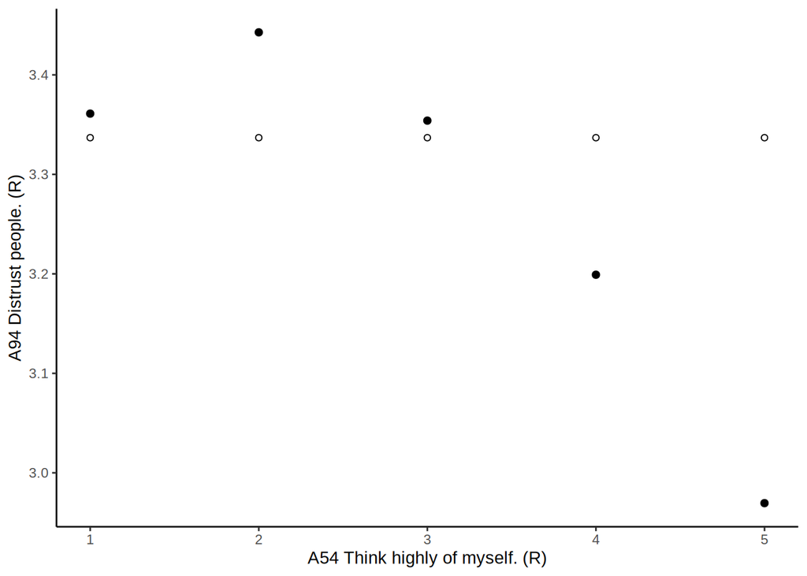

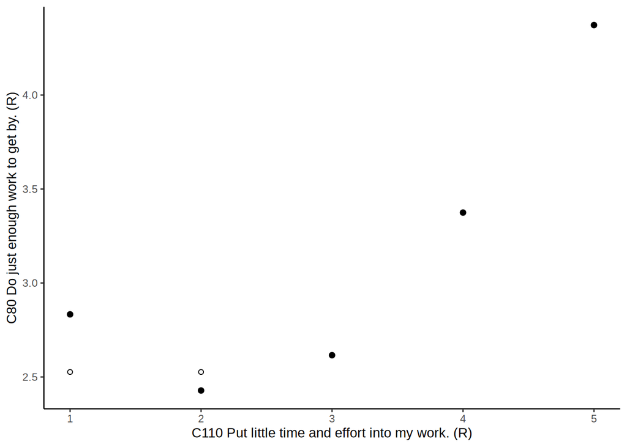

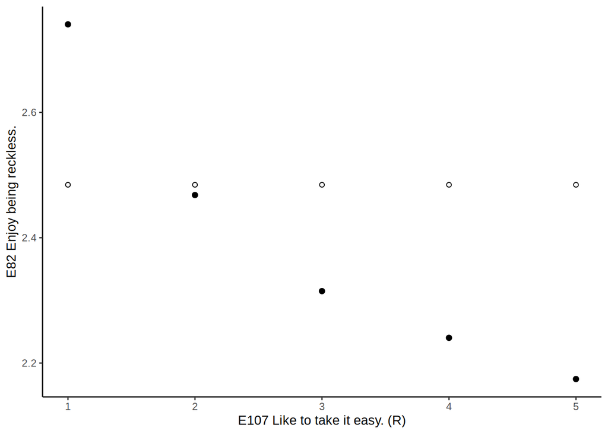

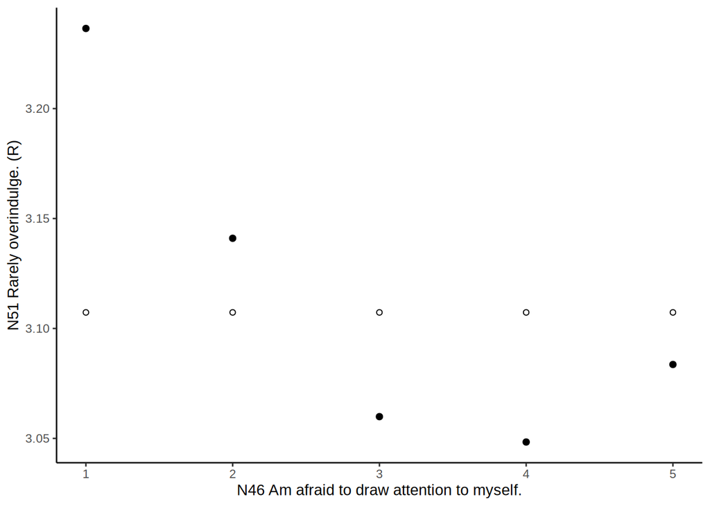

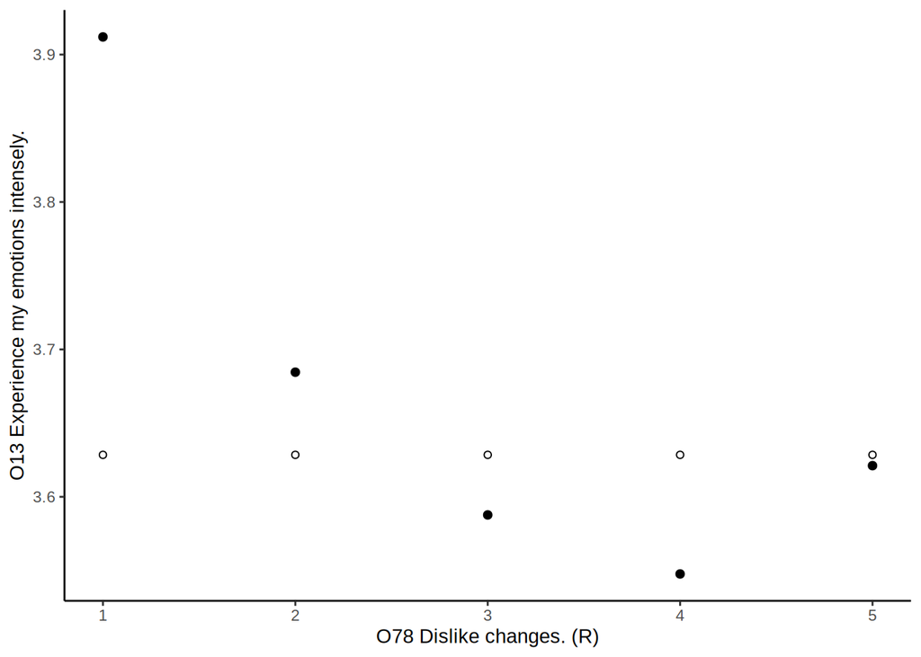

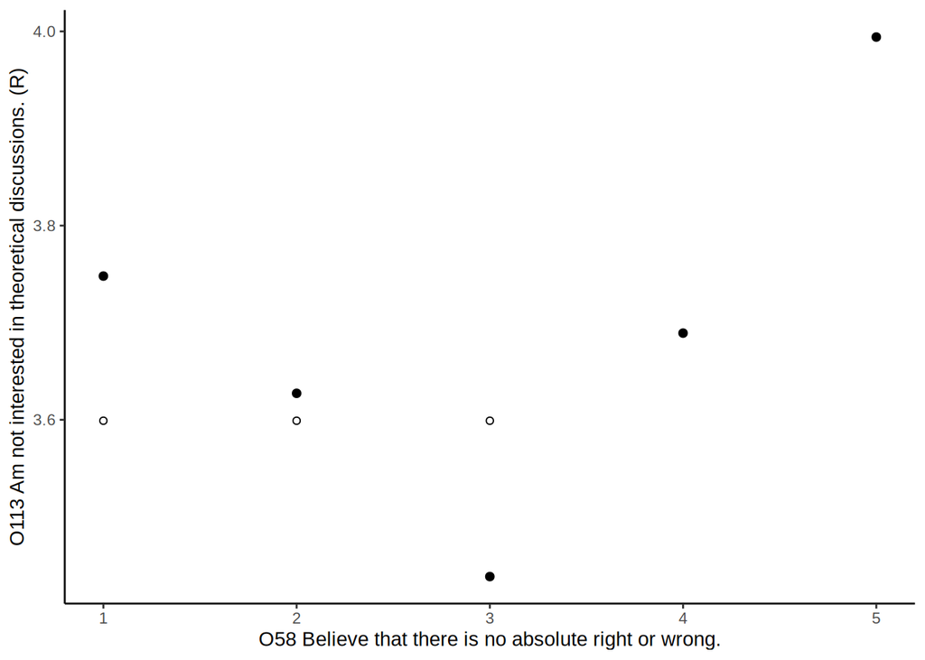

```r
data(ipipneo_items)
items <- ipipneo_items
severe <- arrange(result, -deviance_data) %>%
  group_by(group) %>%
  slice(1:2) %>% ungroup() %>% slice(1, 3, 5, 7, 9, 10)
severe <- severe %>% mutate(item_number_i = as.numeric(substr(i, 2, 4)),
                            item_number_j = as.numeric(substr(j, 2, 4)))
severe <- left_join(severe, items, by = c("item_number_i" = "item_number"))
severe <- left_join(severe, items, by = c("item_number_j" = "item_number"))
severe <- mutate(severe, item_content.x = paste(i, item_content.x),
                 item_content.y = paste(j, item_content.y))
  # slice(1:6, 143, 144, 285, 286)
plots <- Map(function(x, y) plot_it(ipipneo[, c(x, y)], with_n = FALSE), severe$i, severe$j)

plots2 <- Map(function(plot, item_x, item_y) plot + scale_x_continuous(item_x) +
      scale_y_continuous(item_y), plots, severe$item_content.x, severe$item_content.y)
plots2
```

```r
pdf("plots/ipip_neo_severe.pdf", width = 8.5 * 1.1, height =  10 * 1.1)
plot_grid(plotlist = plots2, ncol = 2, labels = "AUTO", label_x = 0.52)
dev.off()
```

## network graph

This code is somewhat messy.

```r
sums <- result %>%
  group_by(i) %>%
  summarize(deviance_sum = sum(deviance_data)) %>%
  arrange(desc(deviance_sum))
```

```r
## network graph -----
vertices <- data.frame(name = unique(c(result$i, result$j)))
vertices$factor <- substr(vertices$name, 1, 1)
vertices$factor_num <- match(vertices$factor,
                             names(c("N" = 1, "E" = 2, "O" = 3, "A" = 4, "C" = 5)))
vertices$facet <- (as.numeric(substr(vertices$name, 2, 4)) %% 30 - vertices$factor_num + 5 ) / 5
vertices$facet <- ifelse(vertices$facet == 0, 6, vertices$facet)
vertices_a <- vertices[vertices$factor != "O", ]

graph1 <- as_tbl_graph(
  graph_from_data_frame(result[!grepl("O", result$i), c("i", "j", "p", "deviance_data", "deviance_norm")],  directed = TRUE,
                        vertices = vertices_a)
)
graph1
```

```
## # A tbl_graph: 73 nodes and 132 edges
## #
## # A directed simple graph with 4 components
## #
## # Node Data: 73 × 4 (active)
##   name  factor factor_num facet
##   <chr> <chr>       <int> <dbl>
## 1 E2    E               2     1
## 2 A4    A               4     1
## 3 E7    E               2     2
## 4 E17   E               2     4
## 5 N21   N               1     5
## 6 E22   E               2     5
## # … with 67 more rows
## #
## # Edge Data: 132 × 5
##    from    to     p deviance_data deviance_norm
##   <int> <int> <dbl>         <dbl>         <dbl>
## 1     1    38     0          255.          16.0
## 2     2    18     0         6314.          79.5
## 3     2    29     0         4997.          70.7
## # … with 129 more rows
```

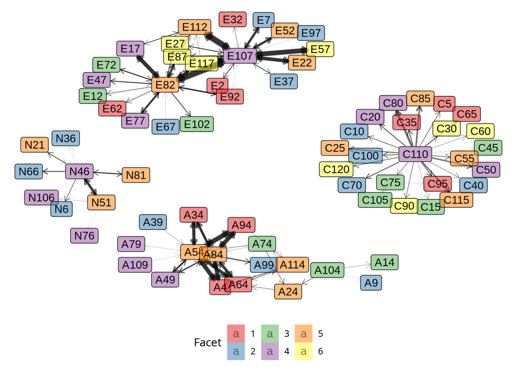

```r
ggraph1 <- ggraph(graph1, layout = "kk") +
  #geom_edge_link(arrow = arrow(length = unit(2, "mm")), end_cap = circle(2, "mm")) +
  geom_edge_link(aes(start_cap = label_rect(node1.name),
                     end_cap = label_rect(node2.name), alpha = 1,
                     show_guide = FALSE,
                     width = deviance_norm),# + #,
                 arrow = arrow(length = unit(2, 'mm')),
                 check_overlap = T) +
  scale_edge_width(range = c(0, 3), name  = "normalized deviance",
                   breaks = seq(0, 18, 1), guide = F) +
  scale_edge_alpha(guide = "none") +
  #geom_node_point(shape = 21, size = 10) +
  #geom_node_text(aes(label = name), color = "black") +
  geom_node_label(aes(label = name, fill = as.factor(facet)), alpha = 0.5) +
  scale_fill_brewer(palette = "Set1", name = "Facet", position = "bottom") +
                  #fill = "lightgrey") +
  theme_graph() +
  theme(plot.margin = unit(c(0.2, 0.1, 0.05, 0.1), "cm"), legend.position = "bottom")
ggraph1
```

```r
graph2 <- as_tbl_graph(
  graph_from_data_frame(result[grepl("O", result$i), c("i", "j", "p", "deviance_data", "deviance_norm")],  directed = TRUE,
                        vertices = vertices[vertices$factor == "O", ]),
)
graph2
```

```
## # A tbl_graph: 24 nodes and 135 edges
## #
## # A directed simple graph with 1 component
## #
## # Node Data: 24 × 4 (active)
##   name  factor factor_num facet
##   <chr> <chr>       <int> <dbl>
## 1 O8    O               3     2
## 2 O13   O               3     3
## 3 O18   O               3     4
## 4 O23   O               3     5
## 5 O28   O               3     6
## 6 O33   O               3     1
## # … with 18 more rows
## #
## # Edge Data: 135 × 5
##    from    to     p deviance_data deviance_norm
##   <int> <int> <dbl>         <dbl>         <dbl>
## 1     1    15     0         226.          15.0
## 2     2     8     0         627.          25.0
## 3     2     9     0          62.3          7.89
## # … with 132 more rows
```

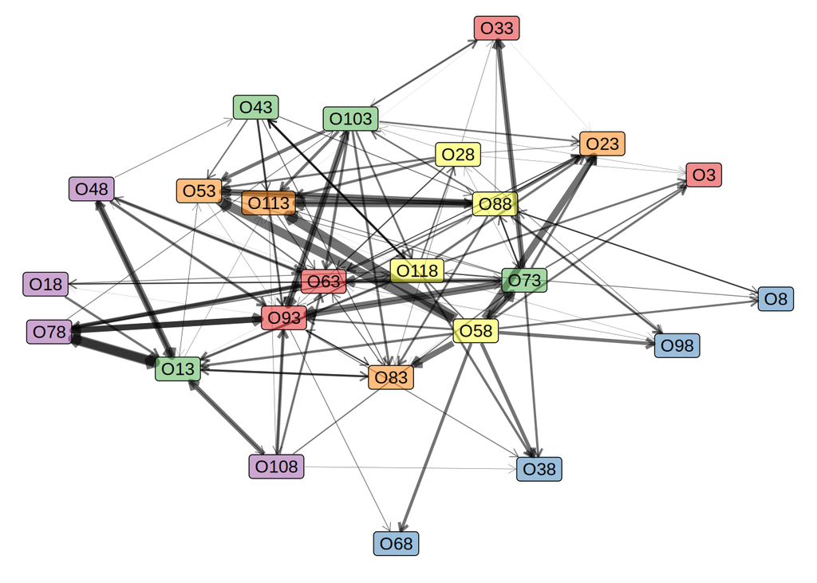

```r
ggraph2 <- ggraph(graph2, layout = "kk") +
  #geom_edge_link(arrow = arrow(length = unit(2, "mm")), end_cap = circle(2, "mm")) +
  geom_edge_link(aes(start_cap = label_rect(node1.name),
                     end_cap = label_rect(node2.name), alpha = 1,
                     width = deviance_norm),
                 arrow = arrow(length = unit(2, 'mm'))) +
  scale_edge_width(range = c(0, 3), name  = "normalized deviance",
                       breaks = seq(0, 18, 1), guide = F) +
  #geom_node_point(shape = 21, size = 10) +
  #geom_node_text(aes(label = name), color = "black") +
  geom_node_label(aes(label = name, fill = as.factor(facet)), alpha = 0.5) +
  scale_fill_brewer(palette = "Set1", name = "Facet") +
  theme_graph() +
  theme(plot.margin = unit(c(0.05, 0.1, 0.2, 0.1), "cm"), legend.position = "none")
ggraph2
```

```r
cairo_pdf("plots/ipip_neo_network_all.pdf", width = 10, height = 14)
plot_grid(ggraph1, ggraph2, nrow = 2)
dev.off()
```

## power analysis for items N51, A84, and liberalism/intellect

```r
i <- rep("N51", 4)
j <- c("N16", "N46", "N76", "N106")

power51 <- create_object(
  ipipneo, i, j, sample_size = 857,
  bootstrap_samples_power = 1e3,
  bootstrap_samples_monoreg = 1e3,
  alpha = 0.05/3
)
simpleCache("powern51", {calculate_power(power51)$power})
powern51
```

```
## [1] 0.143
```

```r
i <- rep("A84", 7)
j <- c("A4", "A34", "A64", "A94", "A99", "A74", "A49")

res <- create_object(
  ipipneo, i, j, sample_size = 857,
  bootstrap_samples_power = 1e3,
  bootstrap_samples_monoreg = 1e3,
  alpha = 0.05/3
)
simpleCache("powera84", {calculate_power(res)$power})
powera84
```

```
## [1] 0.789
```

```r
o6 <- labels %>%
  filter(dimension == "O", facet == 6) %>%
  pull(item_char)
o5 <- labels %>%
  filter(dimension == "O", facet == 5) %>%
  pull(item_char)

grid <- expand.grid(o6, o5, stringsAsFactors = F)

res <- create_object(
  ipipneo, grid$Var1, grid$Var2, sample_size = 857,
  bootstrap_samples_power = 1e3,
  bootstrap_samples_monoreg = 1e3,
  alpha = 0.05/3
)
simpleCache("power_liberalism", {calculate_power(res)$power})
power_liberalism
```

```
## [1] 0.682
```

## most problematic items

```r
result %>%
  group_by(i) %>%
  summarize(sum_dev = sum(deviance_data, na.rm = TRUE)) %>%
  arrange(desc(sum_dev))
```

```
## # A tibble: 64 × 2
##    i     sum_dev
##    <chr>   <dbl>
##  1 E107   60146.
##  2 A54    31055.
##  3 E82    26334.
##  4 A84    21902.
##  5 O58    21075.
##  6 A94    14161.
##  7 C110   12471.
##  8 A4     11655.
##  9 E112   10506.
## 10 E57    10105.
## # … with 54 more rows
```

## c110

One of the most interesting items from the network graph is C110 because it is inconsistent with all other 23 items.

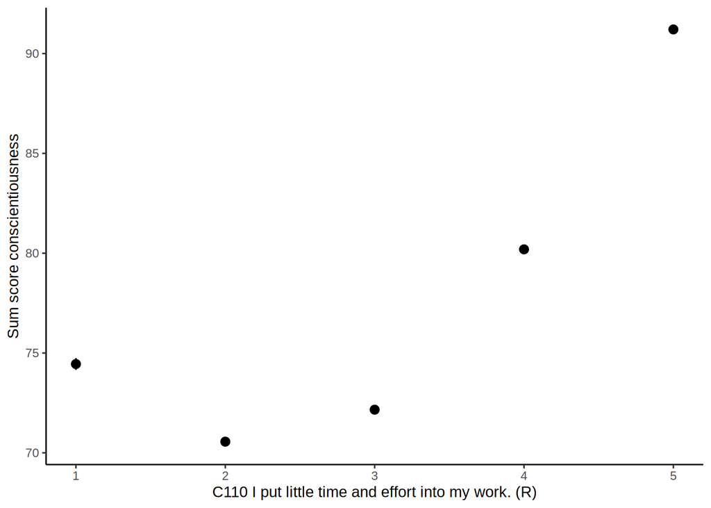

```r
c <- ipipneo %>%
  select(starts_with("C") & !starts_with("C110"))
sum_score <- rowSums(c)
d <- data.frame(C110 = ipipneo$C110, sum_score)
p <- ggplot(d, aes(C110, sum_score)) +
  stat_summary(fun.data = "mean_cl_normal",
               fun.args = list(conf.int = .95)) +
                     theme_classic() +
  scale_x_continuous("C110 I put little time and effort into my work. (R)") +
  scale_y_continuous("Sum score conscientiousness")
p
```

```r
cairo_pdf("plots/c110.pdf", width = 5, height = 4)
p
dev.off()
```

## c110 sem

```r
m0 <- "
  # latent variables
  selfefficacy =~ C5 + C35 + C65 + C95
  orderliness =~ C10 + C40 + C70 + C100
  con3 =~ C15 + C45 + C75 + C105
  con4 =~ C20 + C50 + C80 + C110
  con5 =~ C25 + C55 + C85 + C115
  con6 =~ C30 + C60 + C90 + C120
  c =~ selfefficacy + orderliness + con3 + con4 + con5 + con6
"

ipipneo2 <- ipipneo
ipipneo2$C110[ipipneo2$C110 == 1] <- NA

fit0 <- sem(model = m0, data = ipipneo)
fit1 <- sem(model = m0, data = ipipneo2)

sol0 <- standardizedsolution(fit0, type = "std.all")
sol1 <- standardizedsolution(fit1, type = "std.all")
# facet on C
sol0 %>% filter(lhs == "c", rhs == "con4") %>%
  select(lhs, rhs, est.std)
```

```
##   lhs  rhs est.std
## 1   c con4   0.837
```

```r
# item on facet
sol0 %>% filter(lhs == "con4", rhs == "C110") %>%
  select(lhs, rhs, est.std)
```

```
##    lhs  rhs est.std
## 1 con4 C110   0.649
```

```r
# item on facet after "fix"
sol1 %>% filter(lhs == "con4", rhs == "C110") %>%
  select(lhs, rhs, est.std)
```

```
##    lhs  rhs est.std
## 1 con4 C110   0.709
```

## item E107

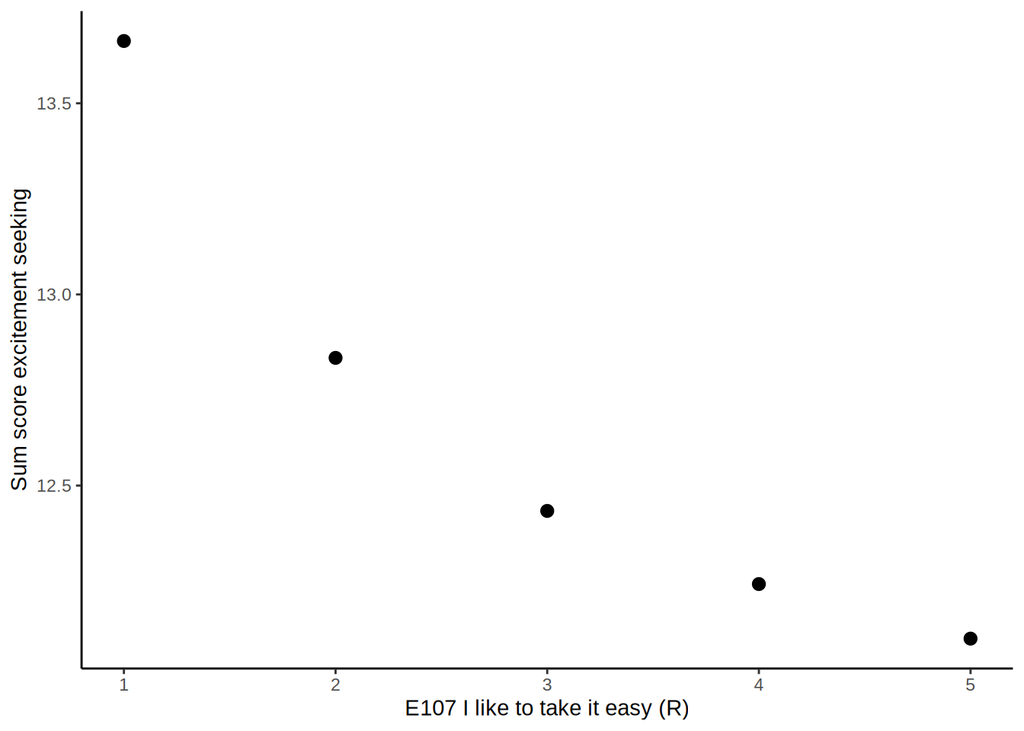

```r
e5 <- labels$item_char[labels$dimension == "E" & labels$facet == 5]
sum_score <- ipipneo %>%
  select(e5) %>%
  rowSums(na.rm = TRUE)
df <- data.frame(E107 = ipipneo$E107, sum_score)
means <- df %>%
  group_by(E107) %>%
  summarize(mean = mean(sum_score, na.rm = TRUE), sd = sd(sum_score, na.rm = TRUE), n())

myplot <- ggplot(means, aes(E107, mean)) +
  geom_point(shape = 20, size = 4) +
  theme_classic() +
  scale_y_continuous("Sum score excitement seeking") +
  scale_x_continuous("E107 I like to take it easy (R)")
myplot
```

```r
cairo_pdf("plots/e107.pdf", width = 5, height = 4)
myplot
dev.off()
```

```r
cor(df, use = "complete.obs")
```

```
##                 E107  sum_score
## E107       1.0000000 -0.1352446
## sum_score -0.1352446  1.0000000
```

```r
cor(ipipneo$E107, ipipneo[, e5], use = "complete.obs")
```

```
##              E22         E52        E82       E112
## [1,] -0.09217619 -0.04590997 -0.1305467 -0.1274152
```

```r
cors <- sort(cor(ipipneo$E107, ipipneo[, grepl("^E", names(ipipneo))], use = "complete.obs"))
mean(cors)
```

```
## [1] 0.06533264
```

```r
tail(cors)
```

```
## [1] 0.1330195 0.1529714 0.1801717 0.1979059 0.2192895 1.0000000
```

```r
head(cors)
```

```
## [1] -0.13050525 -0.12665641 -0.12204025 -0.09153537 -0.05096240 -0.04540997
```

## e107 sem

```r
m0 <- "
  # latent variables
  ex1 =~ E2 +  E32 + E62 + E92
  ex2 =~ E7 +  E37 + E67 + E97
  ex3 =~ E12 + E42 + E72 + E102
  ex4 =~ E17 + E47 + E77 + E107
  ex5 =~ E22 + E52 + E82 + E112
  ex6 =~ E27 + E57 + E87 + E117
  extraversion =~ ex1 + ex2 + ex3 + ex4 + ex5 + ex6
"

m1 <- "
  # latent variables
  ex1 =~ E2 +  E32 + E62 + E92
  ex2 =~ E7 +  E37 + E67 + E97
  ex3 =~ E12 + E42 + E72 + E102
  ex4 =~ E17 + E47 + E77
  ex5 =~ E22 + E52 + E82 + E112
  ex6 =~ E27 + E57 + E87 + E117
  extraversion =~ ex1 + ex2 + ex3 + ex4 + ex5 + ex6
"

fit0 <- sem(model = m0, data = ipipneo)
fit1 <- sem(model = m1, data = ipipneo)

sol0 <- standardizedsolution(fit0, type = "std.all")
sol1 <- standardizedsolution(fit1, type = "std.all")

# facet on C
sol0 %>% filter(lhs == "extraversion", rhs == "ex4") %>%
  select(lhs, rhs, est.std)
```

```
##            lhs rhs est.std
## 1 extraversion ex4   0.436
```

```r
# item on facet
sol0 %>% filter(lhs == "ex4", rhs == "E107") %>%
  select(lhs, rhs, est.std)
```

```
##   lhs  rhs est.std
## 1 ex4 E107   0.244
```

```r
# item on facet after "fix"
sol1 %>% filter(lhs == "extraversion", rhs == "ex4") %>%
  select(lhs, rhs, est.std)
```

```
##            lhs rhs est.std
## 1 extraversion ex4   0.445
```

## liberalism vs. intellect

```r
sum_score <- ipipneo %>% select(all_of(o5)) %>% rowSums(na.rm = TRUE)
sum_score_o6 <- ipipneo %>% select(all_of(o6)) %>% rowSums(na.rm = TRUE)

df <- data.frame(o6 = sum_score_o6, o5 = sum_score)

table(df$o6)
```

```
##
##     1     2     3     4     5     6     7     8     9    10    11    12    13
##     2    31   581 18717 18234 19988 24625 40972 46980 61322 70836 83220 61731
##    14    15    16    17    18    19    20
## 52726 41195 34810 21865 13045  6105  2165
```

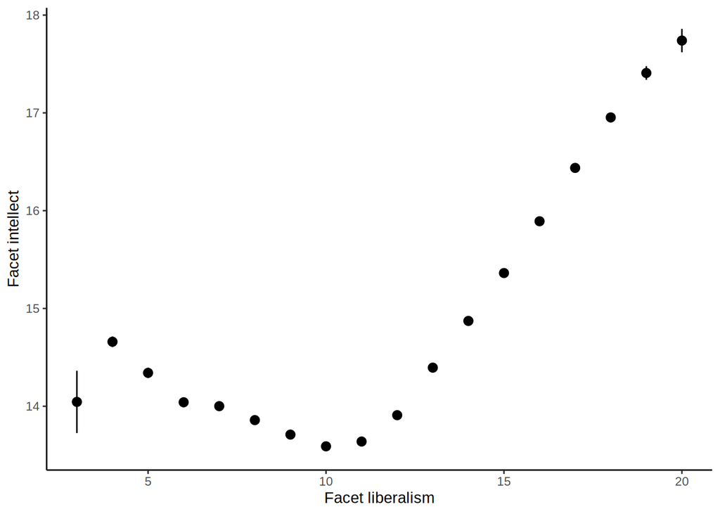

```r
df <- df %>%
  # below 3 there are very few values
  filter(o6 >=3)
myplot <- ggplot(df, aes(o6, o5)) +
  stat_summary(fun.data = "mean_cl_normal") +
               theme_classic() +
                 scale_x_continuous("Facet liberalism") +
                 scale_y_continuous("Facet intellect")
myplot
```

```r
cor(df, use = "complete.obs")
```

```
##           o6        o5
## o6 1.0000000 0.1817898
## o5 0.1817898 1.0000000
```

```r
cairo_pdf("plots/liberalism_intellect2.pdf", width = 5, height = 4)
myplot
dev.off()
```

## Facets modesty and trust

SEMs:

```r
m0 <- "
  # latent variables
  trust =~ A4 + A34 + A64 + A94
  morality =~ A9 + A39 + A69 + A99
  altruism =~ A14 + A44 + A74 + A104
  cooperation =~ A19 + A49 + A79 + A109
  modesty =~ A24 + A114 + A54 + A84
  sympathy =~ A29 + A59 + A89 + A119
  agreeableness =~ modesty + sympathy + trust + morality + altruism + cooperation
"

m1 <- "
  # latent variables
  trust =~ A4 + A34 + A64 + A94
  morality =~ A9 + A39 + A69 + A99
  altruism =~ A14 + A44 + A74 + A104
  cooperation =~ A19 + A49 + A79 + A109
  modesty =~ A24 + A114
  sympathy =~ A29 + A59 + A89 + A119
  agreeableness =~ modesty + sympathy + trust + morality + altruism + cooperation
"

fit0 <- sem(model = m0, data = ipipneo)
fit1 <- sem(model = m1, data = ipipneo)

plot0 <- lavaanPlot(model = fit0,
                    graph_options = list(overlap = "true", fontsize = "10",
                                         rankdir = "LR"),
                    node_options = list(shape = "box", fontsize = "10"),
                    edge_options = list(color = "grey"),
                    coefs = TRUE, stand = TRUE)
plot1 <- lavaanPlot(model = fit1,
                    graph_options = list(overlap = "true", fontsize = "10",
                                         rankdir = "LR"),
                    node_options = list(shape = "box", fontsize = "10"),
                    edge_options = list(color = "grey"),
                    coefs = TRUE, stand = TRUE)
embed_plot_pdf(plot0, "plots/modesty_sem0.pdf")
```

[figure not shown]

```r
embed_plot_pdf(plot1, "plots/modesty_sem1.pdf")
```

[figure not shown]

```r
sol0 <- standardizedsolution(fit0, type = "std.all")
sol1 <- standardizedsolution(fit1, type = "std.all")

facet_factor <- sol0 %>%
  filter(lhs == "agreeableness", rhs != "agreeableness") %>%
  select(lhs, rhs, est.std) %>%
  as.data.frame()
facet_factor1 <- sol1 %>%
  filter(lhs == "agreeableness", rhs != "agreeableness") %>%
  select(lhs, rhs, est.std) %>%
  as.data.frame()
tbl <- cbind(facet_factor, est.std2 = facet_factor1$est.std)
tbl %>%
  mutate(diff = est.std2 - est.std)
```

```
##             lhs         rhs   est.std  est.std2        diff
## 1 agreeableness     modesty 0.1449769 0.7253290  0.58035212
## 2 agreeableness    sympathy 0.7942082 0.7044351 -0.08977306
## 3 agreeableness       trust 0.4329676 0.4229601 -0.01000750
## 4 agreeableness    morality 0.6512873 0.7662657  0.11497843
## 5 agreeableness    altruism 0.9138932 0.8082312 -0.10566192
## 6 agreeableness cooperation 0.6197094 0.7233780  0.10366853
```

```r
r2 <- sum(tbl$est.std**2) / 6
r2b <- sum(tbl$est.std2**2) / 6
r2
```

```
## [1] 0.4137769
```

```r
r2b
```

```
## [1] 0.4941505
```

```r
r2b - r2
```

```
## [1] 0.08037355
```

```r
colnames(tbl) <- c("lhs", "Facet", "Loading", "Loading w/o A54, A84")
print(xtable::xtable(tbl[, -1], caption = "", label = "tab:modesty"),
                     booktabs = T,
    include.rownames = F, file = "tables/modesty.tex")
```

```r
a1_names <- labels %>%
  filter(dimension == "A", facet == 1) %>%
  pull(item_char)

a1_sum_score <- ipipneo %>%
  select(a1_names) %>%
  rowSums(na.rm = TRUE)

a5_names <- labels %>%
  filter(dimension == "A", facet == 5) %>%
  pull(item_char)

a5_sum_score <- ipipneo %>%
  select(a5_names) %>%
  rowSums(na.rm = TRUE)

df <- data.frame(ipipneo[, a5_names], sum_score = a1_sum_score)

res <- lapply(a5_names, get_stats, df)
names(res) <- a5_names
res2 <- plyr::ldply(res, "data.frame")
names(res2)[1] <- "Item"
res2$Item <- factor(res2$Item, levels = a5_names)
mplot <- ggplot(res2, aes(group, mean, ymin = mean - se * qnorm(0.95),
                          ymax = mean + se * qnorm(0.95),
                          group = Item, color = Item, shape = Item)) +
    geom_pointrange() +
    geom_line(linetype = "dashed") +
    scale_x_continuous("Item answer") +
    scale_y_continuous("Sum score trust") +
    scale_color_brewer(type = "div", palette = "Dark2") +
    theme_classic() +
    theme(legend.position = c(0.5, 0.25))
cor(df, use = "complete.obs")
```

```
##                 A24         A54        A84       A114   sum_score
## A24       1.0000000  0.42212438  0.4461389 0.28947825  0.10614862
## A54       0.4221244  1.00000000  0.7981780 0.22208214 -0.09317226
## A84       0.4461389  0.79817797  1.0000000 0.24608195 -0.07670720
## A114      0.2894782  0.22208214  0.2460820 1.00000000  0.04892118
## sum_score 0.1061486 -0.09317226 -0.0767072 0.04892118  1.00000000
```

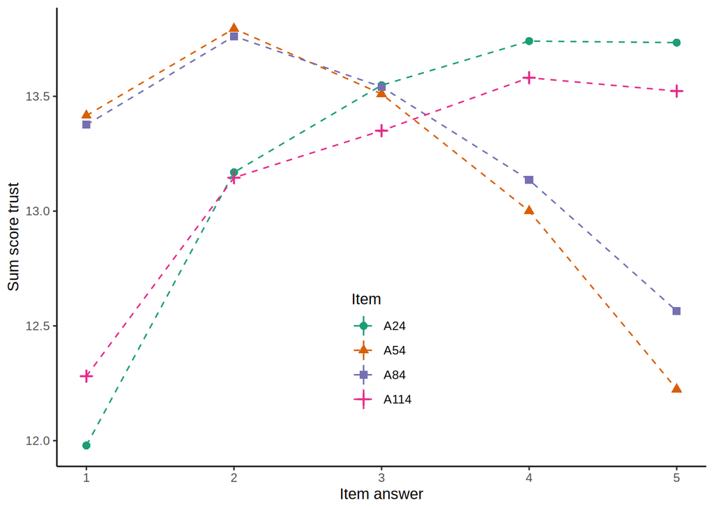

```r
mplot
```

```r
cairo_pdf("plots/modestytrust.pdf", width = 5, height = 4)
mplot
dev.off()
```